[OHI British Columbia](http://www.ohibc.org/) | [OHI Science](http://ohi-science.org) | [Citation policy](https://github.com/OHI-Science/ohiprep/releases)

# OHIBC: data_prep_lsp.Rmd

Compiled on Thu Nov 5 15:09:03 2015 by ohara

# 1 OHIBC Lasting Special Places subgoal (Sense of Place)

Currently, the Lasting Special Places goal model is identical to the OHI Global model: a region’s status is based upon percent of protected area within 1 km inland buffer and percent of protected area within 3 nautical mile offshore buffer, compared to a reference point of 30% protected area.

$X_{LSP} = \frac{\frac{pA_{CMPA}}{pA_{refCMPA}} + \frac{pA_{CP}}{pA_{refCP}}}{2}$

*pA* = percent of area within the inland or offshore buffer; *CMPA* = coastal marine protected area (3nm offshore); *CP* = coastline protected (1km inland); and *refCMPA* = *refCP* = 30% reference point for both measures.

Future changes may incorporate other data sets and MaPP planning zones.

# 2 Data Preparation

## 2.1 Data Sources

WDPA data base

## 2.2 Read in BC WDPA-MPA shapefile

NOTE: If BC WDPA file does not yet exist, `get_wdpa_poly()` creates it from the original WDPA-MPA file. This takes a long time, due to reading in the full WDPA-MPA geodatabase into a SpatialPolygonsDataFrame.

Need to load the WDPA poly into memory for two reasons:

- We need the polygon to help establish the extents for all the rasters to follow.
- Since we need to assign the oldest `STATUS_YR` value to the cell value in the WDPA-MPA raster, we can’t use `gdal_rasterize()`; instead we need `raster::rasterize()` which works from memory.

```r
poly_wdpa_bc <- lsp_get_wdpa_poly()  ### defaults to BC Albers
```

```
## Reading OHIBC WDPA shapefile from:
##   /var/data/ohi/git-annex/bcprep/lsp/spatial, layer = wdpa_bc_bcalb
```

```
## File `/home/ohara/github/ohibc/prep/regions/wdpa_bc_bcalb.shp`: git commit info unavailable.  Not version-controlled in Git?
```

```
## Current shapefile CRS: +proj=longlat +datum=WGS84 +no_defs +ellps=WGS84 +towgs84=0,0,0
## Reprojecting shapefile:
##   Original: +proj=longlat +datum=WGS84 +no_defs +ellps=WGS84 +towgs84=0,0,0
##   New:      +proj=aea +lat_1=50 +lat_2=58.5 +lat_0=45 +lon_0=-126 +x_0=1000000 +y_0=0 +datum=NAD83 +units=m +no_defs +ellps=GRS80 +towgs84=0,0,0
```

Check for invalid geometries, and fix them if required.

```
## Invalid geometries identified:
##                      rgn_name
## 1         Mud Lake Delta Park
## 2               Valhalla Park
## 3     Brackendale Eagles Park
## 4 Lazo Marsh-North East Comox
## 5             Cape Scott Park
## 6                Naikoon Park
## 7     Hesquiat Peninsula Park
## 8                 Pacific Rim
## 9            NEAH CONSERVANCY
##                                                                     warning_msg
## 1   Ring Self-intersection at or near point 1465933.94081435 812108.20315475005
## 2 Ring Self-intersection at or near point 1614475.0505314199 579429.18585829996
## 3       Ring Self-intersection at or near point 1203978.00353489 531640.1974839
## 4   Ring Self-intersection at or near point 1079499.35852811 520252.16956472001
## 5 Ring Self-intersection at or near point 834452.68640384998 631330.06298249995
## 6   Ring Self-intersection at or near point 611388.72948052001 1019310.24898526
## 7 Ring Self-intersection at or near point 964777.49651524995 492472.53841525997
## 8 Ring Self-intersection at or near point 1111351.3645860001 393207.05606565002
## 9 Ring Self-intersection at or near point 868249.28505664004 1552238.3673922501
## All invalid geometries repaired.
```

## 2.3 Set up coastal buffers and base raster

Buffer files are located in `github/ohibc/regions`. LSP uses 1 km inland and 3nm offshore buffers. The base raster will be used to rasterize the WDPA SPDataFrame in a later step, but the extents and projection need to match the extents and projections of the buffers.

- Read in buffer shapefiles to SpatialPolygonsDataFrames
- Create a region list of buffers and WDPA-MPA SpatialPolygonsDataFrames
- From these objects, get the extents and CRS (proj4string)
- Create a base raster from extents, CRS, and resolution.

```
## File `/home/ohara/github/ohibc/prep/regions/ohibc_offshore_3nm.shp`: most recent commit info: commit b4848d164d7ab5393da401425b57d0a540866c1f Author: Casey O'Hara <ohara@nceas.ucsb.edu> Date:   Wed Oct 28 15:07:36 2015 -0700; uncommitted changes = FALSE
## File `/home/ohara/github/ohibc/prep/regions/ohibc_inland_1km.shp`: most recent commit info: commit b4848d164d7ab5393da401425b57d0a540866c1f Author: Casey O'Hara <ohara@nceas.ucsb.edu> Date:   Wed Oct 28 15:07:36 2015 -0700; uncommitted changes = FALSE
```

```
## All shapefiles: CRS = EPSG:3005 NAD83/BC Albers
##   (+proj=aea +lat_1=50 +lat_2=58.5 +lat_0=45 +lon_0=-126 +x_0=1000000 +y_0=0 +datum=NAD83 +units=m +no_defs +ellps=GRS80 +towgs84=0,0,0)
```

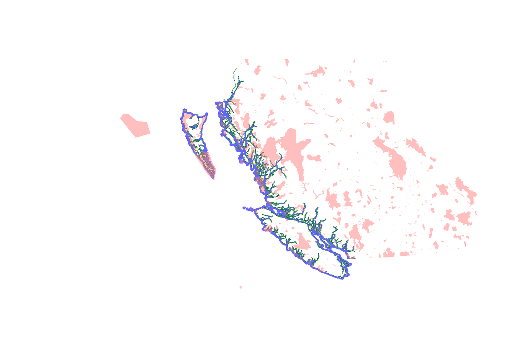

```r
plot(poly_3nm,     col = rgb(.4, .4,  1,  1), border = NA)
plot(poly_1km,     col = rgb( 0, .5,  0,  1), border = NA, add = TRUE)
plot(poly_wdpa_bc, col = rgb( 1, .5, .5, .5), border = NA, add = TRUE)
```

## 2.4 Rasterize the BC WDPA-MPA shapefile

```r
rast_wdpa_bc <- rasterize(poly_wdpa_bc, base_raster, field = 'STATUS_YR', fun = 'min', background = NA,
                          filename = file.path(dir_rst, 'rast_wdpa_bc.tif'), overwrite = TRUE)
```

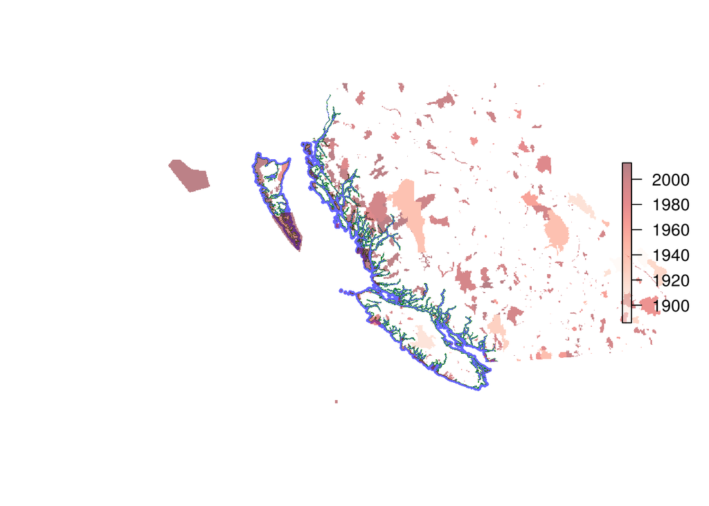

```r
plot(poly_3nm,     col = rgb(.4, .4,  1,  1), border = NA)
plot(poly_1km,     col = rgb( 0, .5,  0,  1), border = NA, add = TRUE)

rast_cols = (colorRampPalette(RColorBrewer::brewer.pal(9, 'Reds'))(255)) # rainbow color scheme

plot(rast_wdpa_bc, col = rast_cols, alpha = 0.5, add = TRUE)
```

# 3 Calculate goal model

## 3.1 Extract WDPA protected areas against buffer regions

Extract the rasterized WDPA against the spatial polygons of the buffer regions. Result is a list of raster cells within each region, and the associated WDPA value (earliest `STATUS_YR`) for that cell.

The result is a dataframe that sums the protected areas within each coastal region (3 nm offshore and 1 km inland, separately)

```r
prot_mar_list <- raster::extract(rast_wdpa_bc, poly_3nm)
names(prot_mar_list) <- poly_3nm@data$rgn_id
prot_mar_df <- lsp_sum_prot_areas(prot_mar_list, reso = res(rast_wdpa_bc)[1])
### note: pull the resolution from the rast_wdpa_bc raster;
### assume x and y resolution are identical

prot_ter_list <- raster::extract(rast_wdpa_bc, poly_1km)
names(prot_ter_list) <- poly_1km@data$rgn_id
prot_ter_df <- lsp_sum_prot_areas(prot_ter_list, reso = res(rast_wdpa_bc)[1])
```

## 3.2 Calculate status for each region for each year

From the sums, determine the ratio of the protected area to the total area within the regions; compare to reference point of 30%; and then take mean of inland score and offshore score.

Eventually this may move to an OHIBC version of `functions.R`, but for now will just calculate directly here.

```r
ref_pt = .3

prot_mar_df <- prot_mar_df %>%
  mutate(ratio = (cum_a_km2/tot_a_km2)/ref_pt*100,
         status = ifelse(ratio > 100, 100, ratio))

prot_ter_df <- prot_ter_df %>%
  mutate(ratio = (cum_a_km2/tot_a_km2)/ref_pt*100,
         status = ifelse(ratio > 100, 100, ratio))

lsp_status <- prot_mar_df %>%
  dplyr::select(rgn_id, year, mar_status = status) %>%
  left_join(prot_ter_df %>%
              dplyr::select(rgn_id, year, ter_status = status),
            by = c('rgn_id', 'year')) %>%
  mutate(status = (mar_status + ter_status) / 2)

write_csv(lsp_status, file.path(dir_lsp, 'data/status.csv'))
git_prov(file.path(dir_lsp, 'data/status.csv'), type = 'output')
```

```
## File `~/github/ohibc/prep/lsp/data/status.csv`: Output not yet committed
```

### 3.2.1 Plot map of status by region

Examining OHIBC Lasting Special Places scores for 1995, 2005, and 2015:

```
## Source: local data frame [7 x 5]
## Groups: rgn_id
##
##   rgn_id year mar_status ter_status     score
## 1      1 1995  0.5747307   5.725731  3.150231
## 2      2 1995  1.8517828  17.531787  9.691785
## 3      3 1995  6.5006647  12.965025  9.732845
## 4      4 1995 14.2734576  21.312087 17.792772
## 5      5 1995 33.2965009  38.994020 36.145260
## 6      6 1995 14.5680888  23.825281 19.196685
## 7      8 1995 39.3481001   4.345127 21.846614
```

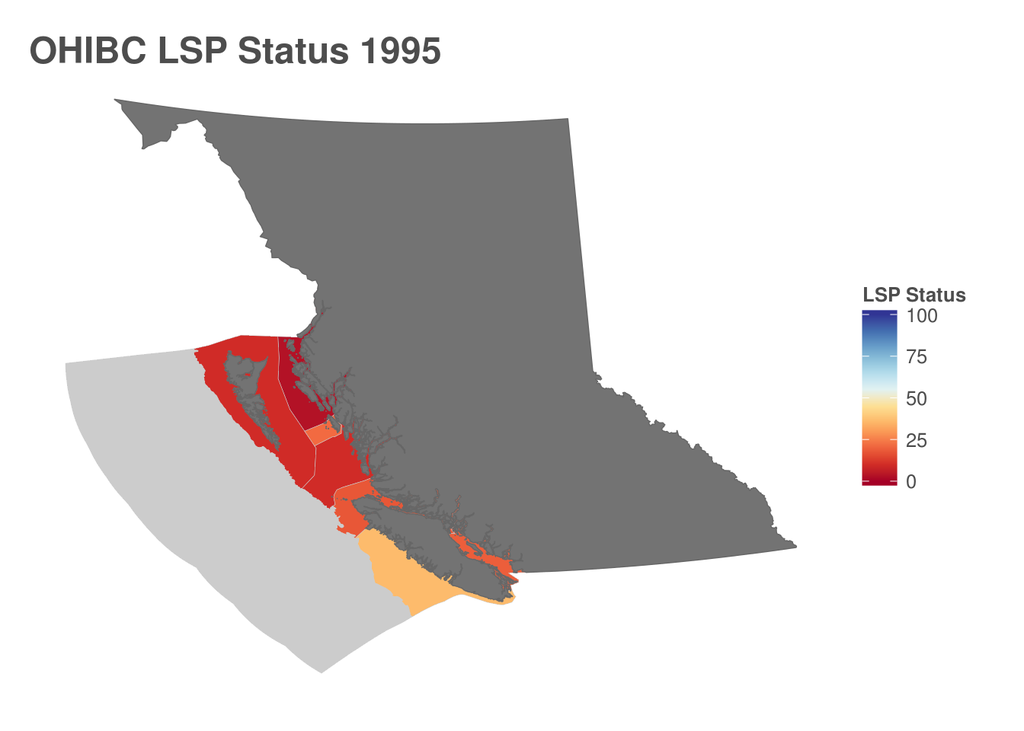

```
## Source: local data frame [7 x 5]
## Groups: rgn_id
##
##   rgn_id year mar_status ter_status     score
## 1      1 2005   1.525649   9.513857  5.519753
## 2      2 2005   2.112772 100.000000 51.056386
## 3      3 2005   6.500665  12.965025  9.732845
## 4      4 2005  14.754439  23.287461 19.020950
## 5      5 2005  52.228361  67.870894 60.049627
## 6      6 2005  17.500367  30.254325 23.877346
## 7      8 2005  39.348100   4.345127 21.846614
```

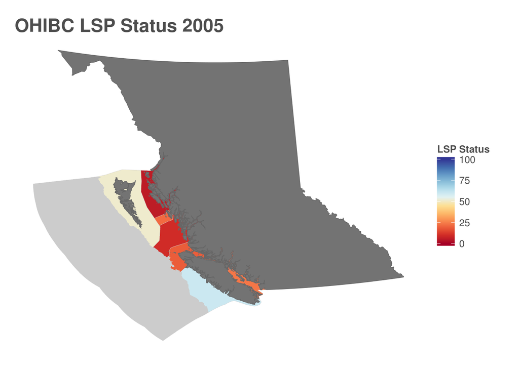

```
## Source: local data frame [7 x 5]
## Groups: rgn_id
##
##   rgn_id year mar_status ter_status     score
## 1      1 2015   22.36225   81.33586  51.84905
## 2      2 2015  100.00000  100.00000 100.00000
## 3      3 2015   51.25961  100.00000  75.62980
## 4      4 2015   20.96820   38.45394  29.71107
## 5      5 2015   52.22836   67.91185  60.07011
## 6      6 2015   17.52702   30.60099  24.06401
## 7      8 2015   39.43814   59.90068  49.66941
```

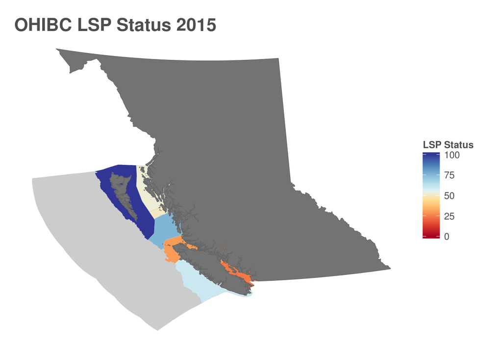

# 4 Provenance

- *Run ID: 2; run tag: “standard run”*
- *System info: System: Linux, Release: 3.2.0-88-generic. Machine: x86_64. User: ohara.*
- *Session info*
  - *R version: R version 3.2.2 (2015-08-14), Platform: x86_64-pc-linux-gnu, Running under: Ubuntu precise (12.04.5 LTS).*
  - *Attached base packages: stats, graphics, grDevices, utils, datasets, methods, base*
  - *Other attached packages: ggplot2_1.0.1, readr_0.1.1, stringr_1.0.0, tidyr_0.2.0, dplyr_0.4.1, cleangeo_0.1, raster_2.3-40, rgdal_1.0-6, rgeos_0.3-11, maptools_0.8-36, sp_1.1-1*

| run_id | run_tag | run_date | file | type | commit_url | commit_author | commit_date | uncommitted_changes |
| --- | --- | --- | --- | --- | --- | --- | --- | --- |
| 2 | standard run | Thu Nov 5 15:18:37 2015 | /home/ohara/github/ohibc/prep/regions/wdpa_bc_bcalb.shp | input | no version control info found |  |  |  |
| 2 | standard run | Thu Nov 5 15:18:37 2015 | /home/ohara/github/ohibc/prep/regions/ohibc_offshore_3nm.shp | input | https://github.com/OHI-Science/ohibc/commit/b4848d164d7ab5393da401425b57d0a540866c1f | Casey O'Hara &lt;ohara@nceas.ucsb.edu&gt; | Wed Oct 28 15:07:36 2015 -0700 | False |
| 2 | standard run | Thu Nov 5 15:18:37 2015 | /home/ohara/github/ohibc/prep/regions/ohibc_inland_1km.shp | input | https://github.com/OHI-Science/ohibc/commit/b4848d164d7ab5393da401425b57d0a540866c1f | Casey O'Hara &lt;ohara@nceas.ucsb.edu&gt; | Wed Oct 28 15:07:36 2015 -0700 | False |
| 2 | standard run | Thu Nov 5 15:18:37 2015 | ~/github/ohibc/prep/lsp/data/status.csv | output | output file: not yet committed |  |  |  |
| 2 | standard run | Thu Nov 5 15:18:37 2015 | ~/github/ohibc/prep/lsp/data_prep_lsp.Rmd | script | https://github.com/OHI-Science/ohibc/commit/050ba8f181f1a46f864780da17869dd146c8a62d | Casey O'Hara &lt;ohara@nceas.ucsb.edu&gt; | Thu Nov 5 13:51:36 2015 -0800 | True |